# Applying symbology based on a variable

You may want to vary the appearance of one or more map features based on the values of an associate variable.

# Required packages

This example uses the following packages:

```r
library(tidyverse)
```

# Sample data

Here is a map of African countries and airports, with lines representing the flights between pairs of airports.

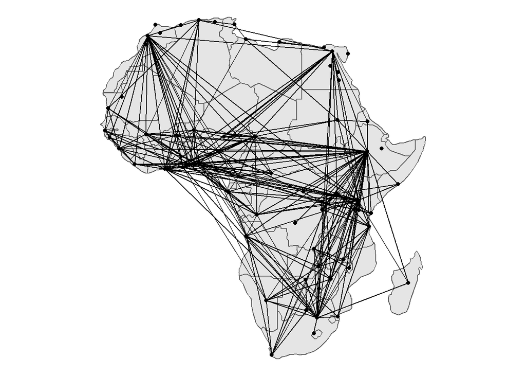

```r
ggplot() +
  geom_sf(data = countries) +
  geom_sf(data = within_africa_flows) +
  geom_sf(data = airports) +
  theme_void()
```

# The aes function

Any settings to vary symbology with a variable will use the `aes()` function. Here are a whole bunch of examples.

# Line symbology

I can vary line width, color, or transparency based on the value of continuous variable. I can vary the line type (e.g. solid or dashed) or the line color based on the value of a categorical variable.

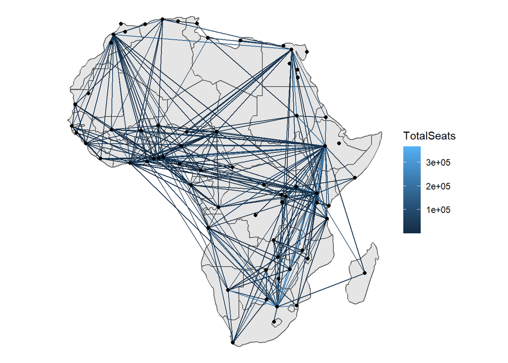

```r
ggplot() +
  geom_sf(data = countries) +
  geom_sf(data = within_africa_flows,
          aes(color = TotalSeats)) +
  geom_sf(data = airports) +
  theme_void()
```

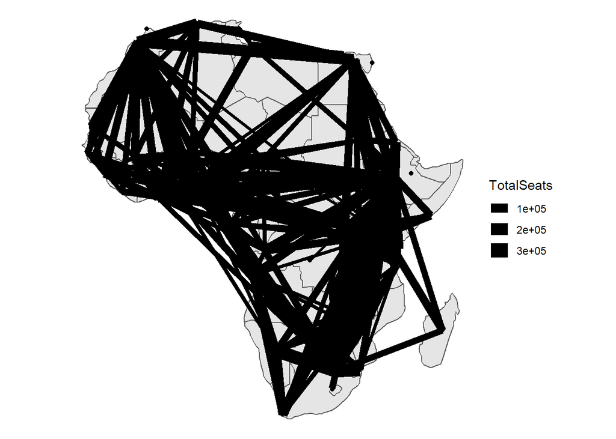

```r
ggplot() +
  geom_sf(data = countries) +
  geom_sf(data = within_africa_flows,
          aes(size = TotalSeats)) +
  geom_sf(data = airports) +
 # scale_size_continuous(range = c(0.5, 3)) +
  theme_void()
```

I can also vary the transparency of the lines.

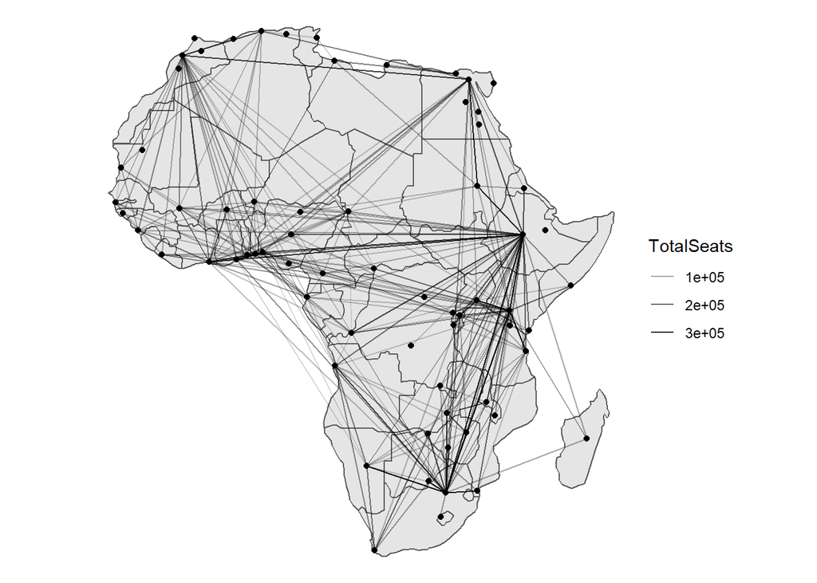

```r
ggplot() +
  geom_sf(data = countries) +
  geom_sf(data = within_africa_flows,
          aes(alpha = TotalSeats)) +
  geom_sf(data = airports) +
  theme_void()
```

And to make things extra clear, I can vary color, thickness, and transparency.

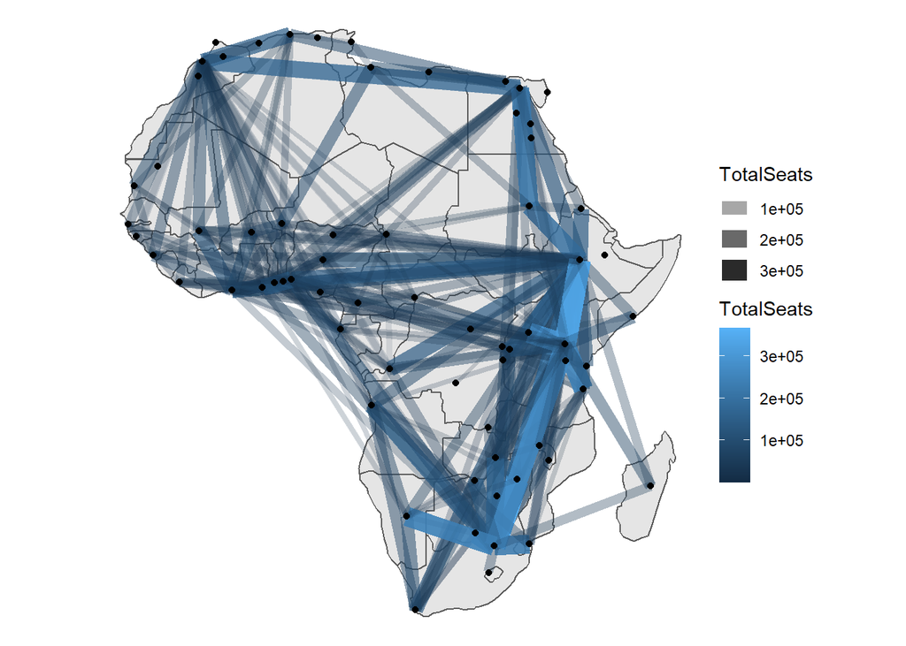

```r
ggplot() +
  geom_sf(data = countries) +
  geom_sf(data = within_africa_flows,
          aes(color = TotalSeats,
              size = TotalSeats,
              alpha = TotalSeats)) +
  geom_sf(data = airports) +
  theme_void()
```

For categorical variables, I can vary the line type:

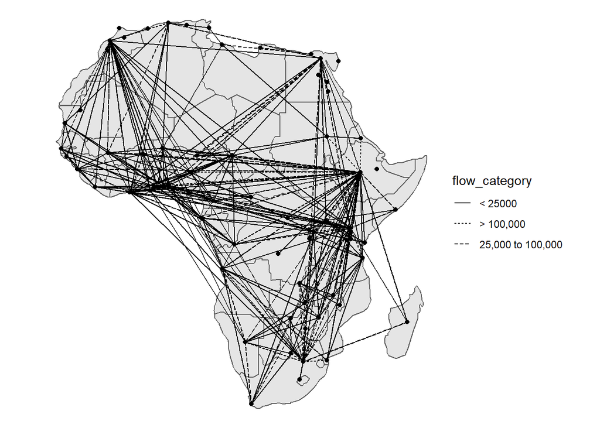

```r
ggplot() +
  geom_sf(data = countries) +
  geom_sf(data = within_africa_flows,
          aes(lty = flow_category)) +
  geom_sf(data = airports) +
  theme_void()
```

Or the line color:

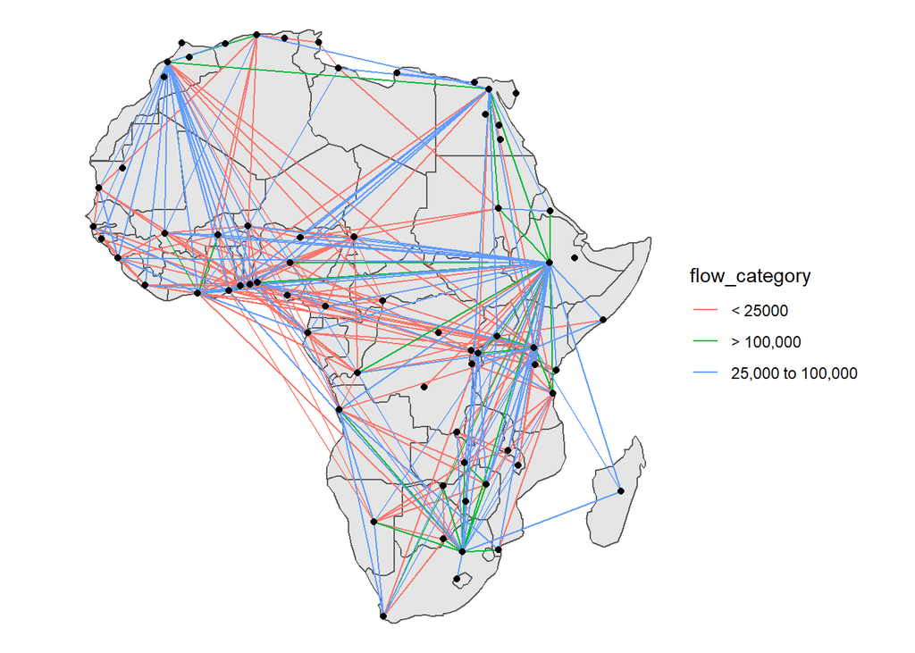

```r
ggplot() +
  geom_sf(data = countries) +
  geom_sf(data = within_africa_flows,
          aes(color = flow_category)) +
  geom_sf(data = airports) +
  theme_void()
```

Or both:

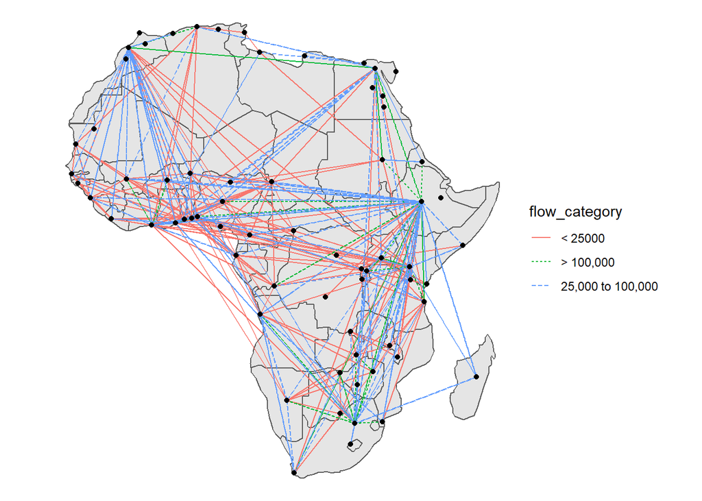

```r
ggplot() +
  geom_sf(data = countries) +
  geom_sf(data = within_africa_flows,
          aes(color = flow_category,
              lty = flow_category)) +
  geom_sf(data = airports) +
  theme_void()
```

# Point symbology

For points, you can vary the color, size, and transparency for continuous variables, or the color or shape for categorical variables.

Varying color, size, and transparency work the same way for points as for lines.

Varying color by number seats arriving annually:

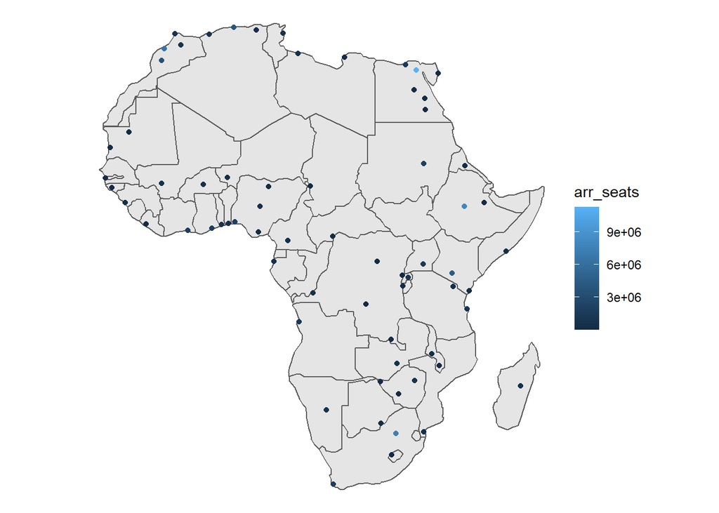

```r
ggplot() +
  geom_sf(data = countries) +
  geom_sf(data = airports,
          aes(color = arr_seats)) +
  theme_void()
```

Varying size:

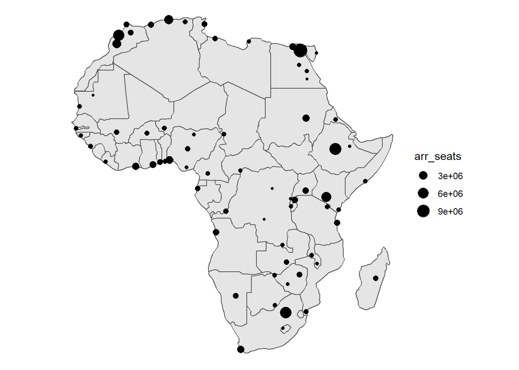

```r
ggplot() +
  geom_sf(data = countries) +
  geom_sf(data = airports,
          aes(size = arr_seats)) +
  theme_void()
```

Varying transparency:

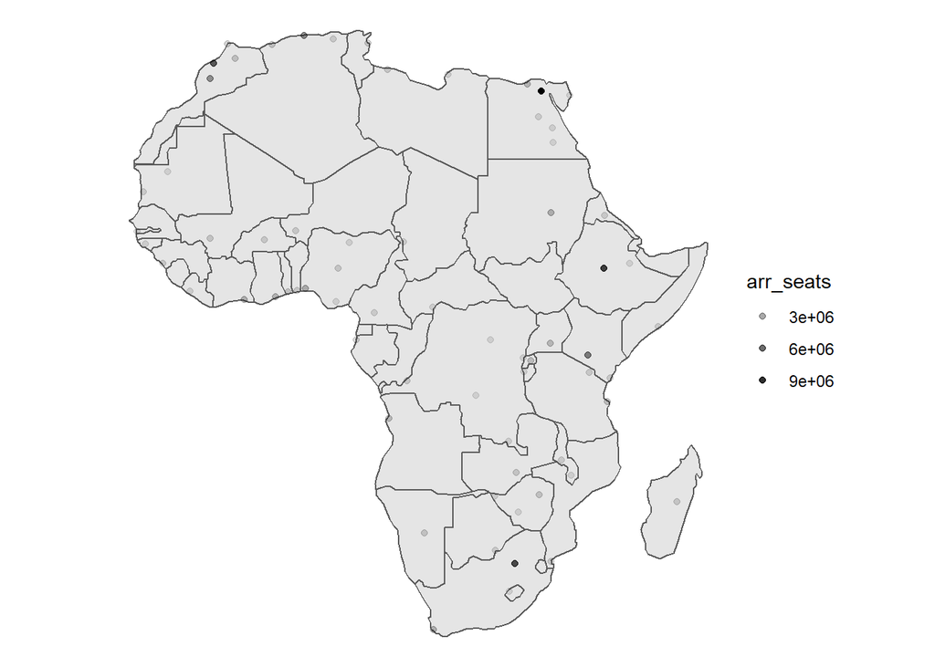

```r
ggplot() +
  geom_sf(data = countries) +
  geom_sf(data = airports,
          aes(alpha = arr_seats)) +
  theme_void()
```

And varying all three:

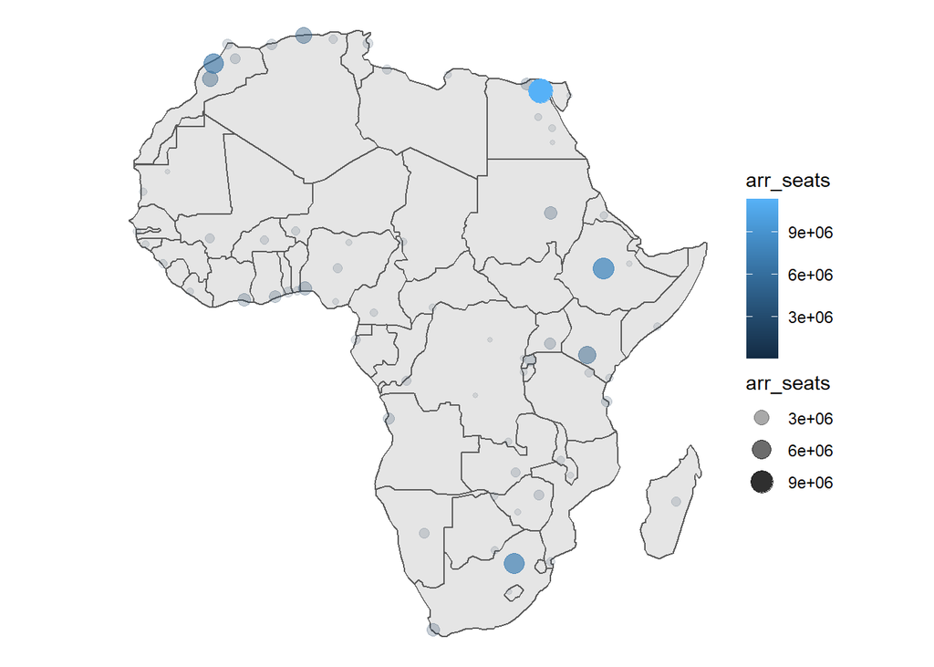

```r
ggplot() +
  geom_sf(data = countries) +
  geom_sf(data = airports,
          aes(color = arr_seats,
              size = arr_seats,
              alpha = arr_seats)) +
  theme_void()
```

For categorical variables, you can also vary the shape of the points.

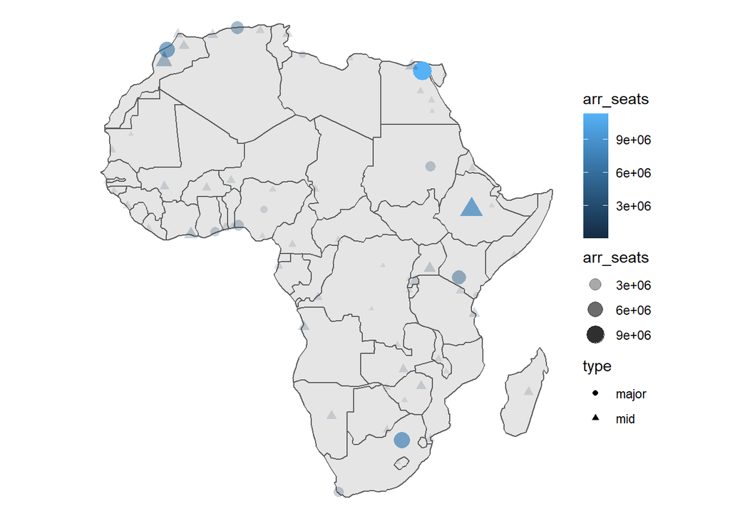

```r
ggplot() +
  geom_sf(data = countries) +
  geom_sf(data = airports,
          aes(color = arr_seats,
              size = arr_seats,
              alpha = arr_seats,
              shape = type)) +
  theme_void()
```

# Polygon symbology

For polygons, you can vary the fill color for continuous or categorical variables, and the fill transparency for continuous variables. You can also vary all the borders of the polygons the same way you would vary line symbology.

Here’s how I would vary the fill color:

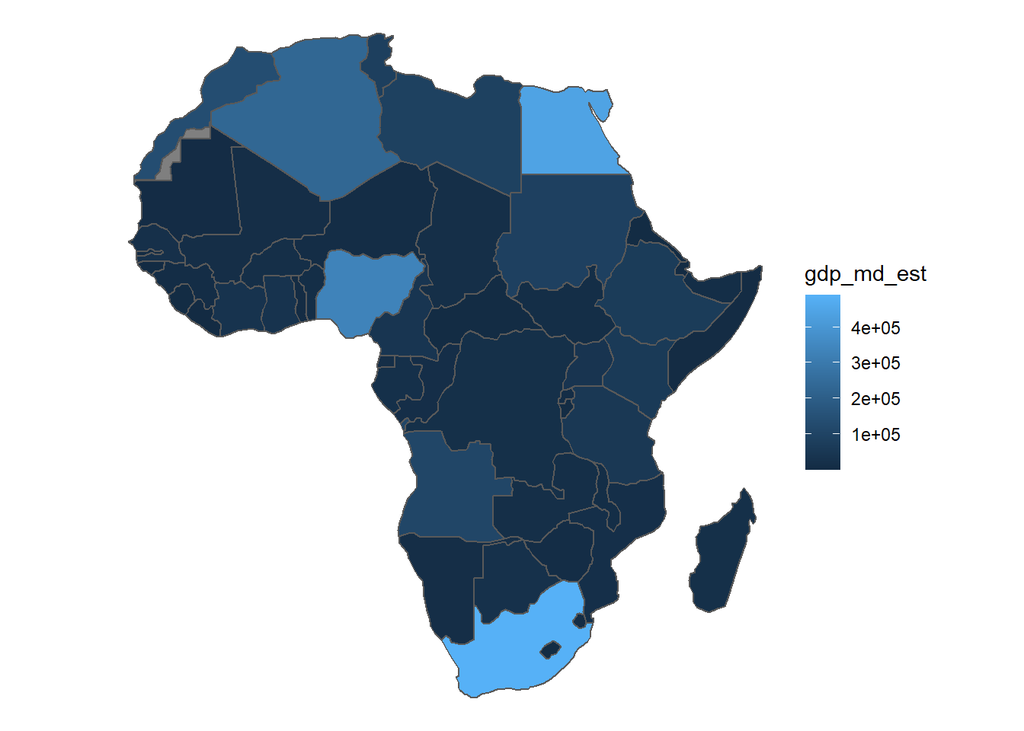

```r
ggplot(countries) +
  geom_sf(aes(fill = gdp_md_est)) +
  theme_void()
```

Or the fill transparency:

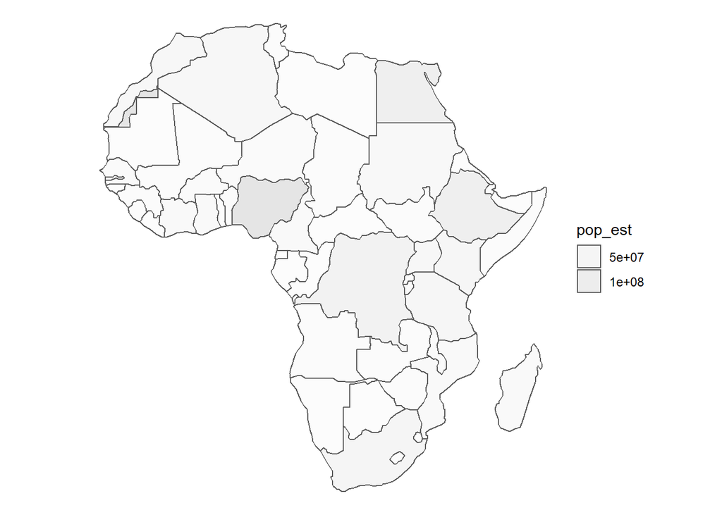

```r
ggplot(countries) +
  geom_sf(aes(alpha = pop_est)) +
  theme_void()
```

Note that `fill` refers to the fill color and `color` refers to the border color

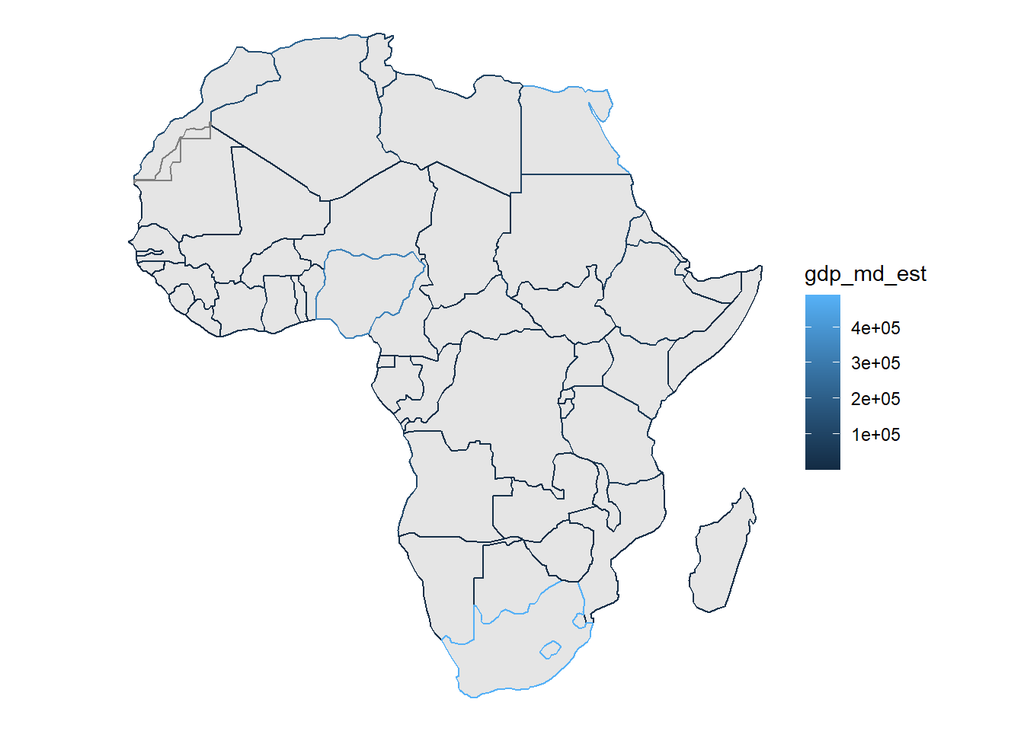

```r
ggplot(countries) +
  geom_sf(aes(color = gdp_md_est)) +
  theme_void()
```